# Newtech - Metagenomics on milk (Spallanzani + CREA-ZA)

Nelson Nazzicari

2022-11-02

# 1 Document history

- 2020-11-04 - initial report
- 2020-11-09 - added section on bovine genome
- 2020-11-16 - added section on filtering, control samples, a first pass for milk samples
- 2020-11-16 - answer to open question 3
- 2020-11-17 - added heatmaps for frequencies at various taxonomic levels
- 2020-11-30 - added diversity analysis, alpha
- 2020-12-01 - added genus level for control samples, added reference to duplicate samples notes
- 2020-12-07 - added beta diversity, rarefaction curves, open question about diary homogeneity
- 2021-02-16 - added summary for bioinformatics analysis (in Italian)
- 2021-02-28 - started rewriting the whole report using the new, local database
- 2021-03-10 - started rewriting the whole report using the new, local database (second iteration)
- 2021-03-11 - moved from up_to_10k to up_to_200k
- 2021-04-07 - added beta plot by silage
- 2021-04-30 - new iteration of database, the third one
- 2022-10-13 - removed control samples from heatmaps

# 2 Aim

Metabarcoding analysis on Grana Padano milk, focusing on vegetable presence. Plant sequences are restricted to a hand picked database containing plants permitted by the Grana Padano consortium rules, plus a selection of Italian flora.

# 3 Current database

```
## Hand picked DB with Grana Padano + Italian plants, second iteration, delivery_20210308
```

# 4 Available samples

## 4.1 Notes on samples

Here’s an exchange with Anna and Rossana, for future reference:

- il campione con id_sample 10, 17 e 21 (ID_lab:177), è sempre lo stesso campione ma:
  - 10 e 17 due aliquote (per motivi di metodo estrattivo) della stessa estrazione ma con curve al nanodrop diverse;
  - 21 stesso campione di latte ma estratto con scala small (cioè meno volume per un tentativo iniziale di miniaturizzare)
- campione id_sample 9 e 22 (ID_lab:387): stesso campione di latte ma estratto con scala small (cioè men volume per un tentativo iniziale di miniaturizzare)

## 4.2 Notes on the custom database

Here’s an exchange with Slobodanka from IGA, for future reference:

Abbiamo interogato due db, quella con le sequenze di lunghezza massima di 10kb (up_to_10kb) e quella che contiene anche interi cloroplasti (up_to_200kb).

Ecco i dettagli sulla creazione del db up_to_200kb:

Lista originale (una volta rimosse le due celle vuote): rbcL_database_20210303.list.txt.orig

Ottenuta dal cliente una lista di 1938 accessioni da scaricare e da usare come db

Dopo aver epurate le accessioni con due o più copie siamo scesi a 1834 accessioni

Scaricate le sequenze con lo script Perl getSeqEMBL.pl oppure manualmente, a seconda delle diverse accessioni

Tolta l’accessione PQIB00000000.2 che è un assembly intero (con 1306 sequenze) e tenuta dalla lista l’accessione PQIB02001306.1 che è uno dei contig sopra

| type | samples | Id_Lab |
| --- | --- | --- |
| broken | 1 | 998 |
| ctrl | 3 | GT, N, S |
| grana | 42 | 479, 252ccf, 431, 842, 480, 935, 1051ccf, 19, 219, 1358, 493, 811, 1490, 1242, 231, 812, 387, 387, 78, 177, 177, 177, 324, 1319, 782, 192, 1294, 1089, 294, 819, 775, 166, 350ccf, 857, 335, 998, 3000, … |
| non-grana | 4 | Naples, Sicily, Apulia, Mountain |

where “broken” indicates a non viable sample which was then re-sent and sequenced, “ctrl” indicate pure vegetable samples (e.g. fodder), “grana” and “non-grana” indicates milk samples from inside and outside Grana Padano areas, respectively.

## 4.3 By province

| province | samples | Id_Lab |
| --- | --- | --- |
| - | 7 | GT, N, S, Naples, Sicily, Apulia, Mountain |
| BS | 8 | 479, 252ccf, 431, 842, 480, 935, 1051ccf, 19 |
| CN | 3 | 219, 1358, 493 |
| CR | 13 | 811, 1490, 1242, 231, 812, 387, 387, 78, 177, 177, 177, 324, 1319 |
| PC | 3 | 782, 192, 1294 |
| TN | 10 | 1089, 294, 819, 775, 166, 350ccf, 857, 335, 998, 3000 |
| VI | 3 | 703, 142, 1230 |
| VR | 2 | 205, 894 |

## 4.4 By extraction method

Two extraction methods have been tested but at the end we will only work with phenol.

# 5 Fraction of Bovine genome

After a mail exchange with Slobodanka Radovic I obtained the OTU table for the second delivery, containing the numerosities for 27 samples, plus the sequences for each of the 4811 centroids analyzed.

A first analysis of the centroid cumulative numerosity led to the following plot:

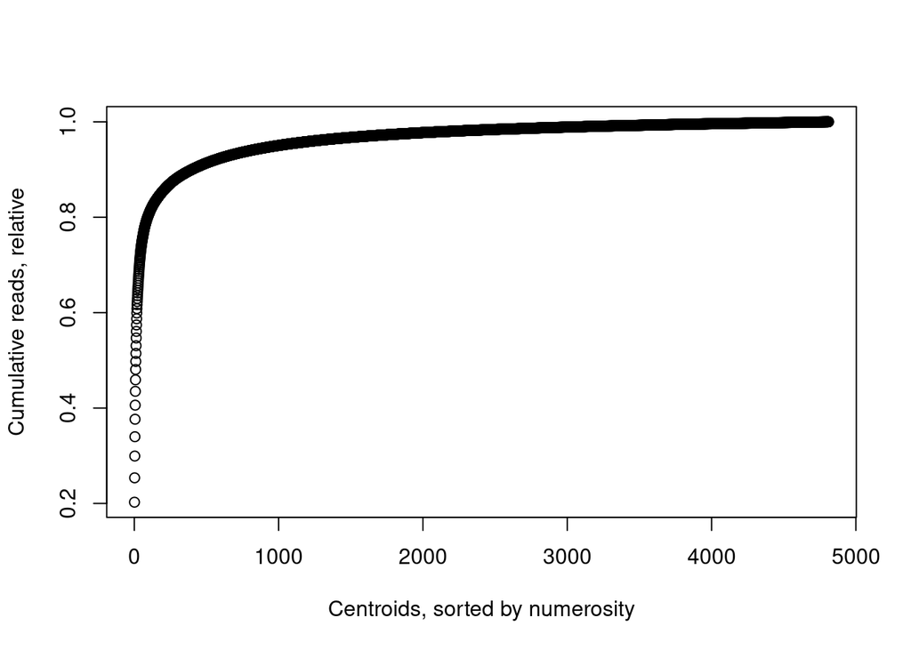

For reference, the 10 most numerous centroids account for the 49.771 % of all the reads.

To investigate what fraction of the available reads have bovine origin I’ve blasted the centroid sequences on the *Bos Taurus* genome via the [NCBI website](https://blast.ncbi.nlm.nih.gov/Blast.cgi?PAGE_TYPE=BlastSearch&PROG_DEF=blastn&BLAST_PROG_DEF=megaBlast&BLAST_SPEC=OGP__9913__10708).

The sequencing results are filtered with the following criteria:

- percent identity > 0.95
- e-value < 1e-5
- in case of multiple alignments I keep the one with smallest e_value

After the filtering 3022 centroids align on the bovine genome, representing the 62.814 % of the total 4811 centroids. In terms of reads, the 63.404 % of reads are bovine.

## 5.1 OPEN QUESTION 1: what fraction of unassigned data is bovine, exactly?

So far I’ve done a high level analysis of centroids, but it would be better to operate sample-by-sample.

# 6 Filtering and conventions

This filtering strategy is taken straighforward from the [published paper on metabarcoding in grana padano](https://www.sciencedirect.com/science/article/pii/S0740002020302021?casa_token=pwjIEIBIUI0AAAAA:UAhVfUNTpp9OOG_iTAWkdc9GKUiy4cd1Ho2On19p80QX8MZHb-MCbDbnFn3a66D3DTn8XqerzTk). We may want to review these values at a later time. The current plan is:

- entries having less than 5 reads are removed and binned to unassigned (UN)
- entries (species?) representing 1% of the reads of a sample will be labeled “subdominant” and will be considered less important in the analysis

The taxonomic hierarchy we used is:

- reads
- domain
- clade/phylum
- class
- order
- family
- subfamily
- tribe
- subtribe
- genus
- species

with some levels (e.g. clade, subtribe) often absent.

# 7 Control samples

In this section I focus on the three control samples: GT (“MANGIME X GP”), N (“NUCLEO”), S (“SOIA”), with the following expected compositions:

- S: soy (glycine max)
- GT: soy (48%), girasole (36%), “tritello” (triticum wheat), maize, “cruscami” (???, low percentage anyway)
- N: to be investigated

| Id_Lab | Label_IGA | type | caseificio | MESE | data_prelievo | Insilato | province |
| --- | --- | --- | --- | --- | --- | --- | --- |
| GT | ID1557-12 | ctrl | [NON-GRANA] |  |  |  | - |
| N | ID1557-13 | ctrl | [NON-GRANA] |  |  |  | - |
| S | ID1557-14 | ctrl | [NON-GRANA] |  |  |  | - |

Taking a look at the assigned **domains** we get:

|  | Eukaryota % | UN % |
| --- | --- | --- |
| [NON-GRANA]_GT_ID1557-12 | 99.1 | 0.919 |
| [NON-GRANA]_N_ID1557-13 | 99.1 | 0.891 |
| [NON-GRANA]_S_ID1557-14 | 99.6 | 0.385 |

Where “UN” means unassigned reads. All in all most of the reads are assigned, as expected in control samples. If we go deeper into the taxonomic tree, at **family** level we find (click on column names to reorder):

|  | GT | N | S |
| --- | --- | --- | --- |
| Convolvulaceae | 0.264 | 0.13 | 0.006 |
| Fabaceae | 24.37 | 17.295 | 99.475 |
| Malvaceae | 2.336 | 3.303 | 0.019 |
| Poaceae | 69.313 | 74.756 | 0.058 |
| Rubiaceae | 0.181 | 0.065 | 0 |
| UN | 1.217 | 1.149 | 0.406 |
| Asteraceae | 1.648 | 2.39 | 0.012 |
| Euphorbiaceae | 0.009 | 0.005 | 0.023 |
| Linaceae | 0.32 | 0.209 | 0 |
| Ranunculaceae | 0.337 | 0.661 | 0 |

[output cut: 2 more lines]

This table still is quite usable, but shows a trend: the number of unassigned entries grows when we go deeper into the taxonomy tree. Going down to **genus** level:

|  | GT | N | S |
| --- | --- | --- | --- |
| Cuscuta | 0.264 | 0.13 | 0.006 |
| Galium | 0.181 | 0.065 | 0 |
| Glycine | 16.28 | 14.388 | 99.394 |
| Gossypium | 2.184 | 2.366 | 0.019 |
| Medicago | 0.076 | 0.094 | 0 |
| Pisum | 5.325 | 1.022 | 0 |
| Triticum | 0.004 | 0.008 | 0 |
| UN | 68.757 | 75.131 | 0.466 |
| Vicia | 0.027 | 0.019 | 0.004 |
| Avena | 0.023 | 0.012 | 0 |

[output cut: 18 more lines]

And to **species** level:

|  | GT | N | S |
| --- | --- | --- | --- |
| Glycine max | 16.202 | 14.269 | 99.339 |
| Medicago sativa | 0.072 | 0.073 | 0 |
| Pisum sativum | 5.325 | 1.022 | 0 |
| Triticum aestivum | 0.004 | 0.008 | 0 |
| UN | 71.078 | 77.739 | 0.524 |
| Vicia faba | 0 | 0 | 0.004 |
| Avena sativa | 0.023 | 0.012 | 0 |
| Ceratonia siliqua | 2.574 | 1.682 | 0.076 |
| Cuscuta monogyna | 0.022 | 0 | 0 |
| Cuscuta reflexa | 0.238 | 0.127 | 0 |

[output cut: 25 more lines]

This is to show that we may need to operate at a level different from **species**, or risk losing a lot of information.

## 7.1 OPEN QUESTION 2: what taxonomic level?

How to decide what taxonomic level to use? I’ve read a few metabarcoding papers that use phylum/family. Would it be ok? Further data exploration will probably give us more hints.

# 8 Milk samples - reads and vegetable portion

The first step is to take a look to **domain** level for milk samples. In this table I report all the metadata (province, date and so forth). I then have three data columns:

- Eukaryota: percentage of reads, for each sample, classified as Eukaryota
- UN : as above, but for unassigned reads
- Reads: absolute number of reads for that sample

Here’s the table, sorted by decreasing number of unassigned:

| Id_Lab | Label_IGA | type | caseificio | MESE | data_prelievo | Insilato | province | Eukaryota | UN | reads |
| --- | --- | --- | --- | --- | --- | --- | --- | --- | --- | --- |
| 205 | ID1701-10 | grana | VR916 | DIC_2017 | 13/12/2017 | SI | VR | 1.022 | 98.978 | 137921 |
| 1294 | ID1701-21 | grana | PC527 | AGO_2018 | 28/08/2018 | SI | PC | 1.776 | 98.224 | 188069 |
| 894 | ID1701-11 | grana | VR916 | MAG_2018 | 18/05/2018 | SI | VR | 2.057 | 97.943 | 192245 |
| 775 | ID1701-12 | grana | TN316 | APR_2018 | 20/04/2018 | NO | TN | 2.126 | 97.874 | 181028 |
| 703 | ID1701-22 | grana | VI611 | APR_2018 | 06/04/2018 | SI | VI | 2.383 | 97.617 | 249291 |
| 782 | ID1701-19 | grana | PC527 | APR_2018 | 23/04/2018 | SI | PC | 2.647 | 97.353 | 192999 |
| 935 | ID1701-17 | grana | BS634 | MAG_2018 | 31/05/2018 | SI | BS | 2.866 | 97.134 | 237996 |
| 78 | ID1701-4 | grana | CR117 | NOV_2017 | 17/11/2017 | SI | CR | 3.247 | 96.753 | 172051 |
| 142 | ID1701-23 | grana | VI611 | DIC_2017 | 01/12/2017 | SI | VI | 3.425 | 96.575 | 164833 |
| 252ccf | ID1701-2 | grana | BS601 | DIC_2017 | 21/12/2017 | SI | BS | 3.472 | 96.528 | 169562 |

[output cut: 31 more lines]

In summary

```
## Total reads: 8399591
```

```
## Average per sample: 204868.073170732
```

```
## Range: 37002 - 408724
```

## 8.1 [CLOSED] OPEN QUESTION 3: are these reads levels ok?

I think I need to check with Slobodanka again, at least to confirm that this is expected.

**ANSWER**: it appears that the reads levels are acceptable, she suggests subsampling/oversampling reads if we need to normalize the samples (we don’t, we’ll use frequencies).

# 9 Milk, OTUs

With control samples:

| level | samples | OTUs_all | OTUs_filter5 | OTUs_filter5_dominant | mean_unassigned |
| --- | --- | --- | --- | --- | --- |
| clade_phylum | 49 | 1 | 1 | 1 | 0.873 |
| family | 49 | 11 | 11 | 7 | 0.894 |
| genus | 49 | 31 | 28 | 15 | 0.924 |
| species | 49 | 50 | 38 | 16 | 0.945 |

Removing control samples:

| level | samples | OTUs_all | OTUs_filter5 | OTUs_filter5_dominant | mean_unassigned |
| --- | --- | --- | --- | --- | --- |
| clade_phylum | 46 | 1 | 1 | 1 | 0.930 |
| family | 46 | 11 | 8 | 7 | 0.952 |
| genus | 46 | 26 | 17 | 14 | 0.953 |
| species | 46 | 37 | 19 | 14 | 0.974 |

Removing control samples, GP only:

| level | samples | OTUs_all | OTUs_filter5 | OTUs_filter5_dominant | mean_unassigned |
| --- | --- | --- | --- | --- | --- |
| clade_phylum | 42 | 1 | 1 | 1 | 0.930 |
| family | 42 | 10 | 8 | 7 | 0.953 |
| genus | 42 | 25 | 16 | 14 | 0.954 |
| species | 42 | 36 | 16 | 14 | 0.974 |

Removing control samples, commercial only:

| level | samples | OTUs_all | OTUs_filter5 | OTUs_filter5_dominant | mean_unassigned |
| --- | --- | --- | --- | --- | --- |
| clade_phylum | 4 | 1 | 1 | 1 | 0.930 |
| family | 4 | 9 | 5 | 5 | 0.941 |
| genus | 4 | 16 | 9 | 8 | 0.941 |
| species | 4 | 16 | 8 | 5 | 0.967 |

Just control samples:

| level | samples | OTUs_all | OTUs_filter5 | OTUs_filter5_dominant | mean_unassigned |
| --- | --- | --- | --- | --- | --- |
| clade_phylum | 3 | 1 | 1 | 1 | 0.007 |
| family | 3 | 11 | 11 | 4 | 0.009 |
| genus | 3 | 30 | 27 | 9 | 0.481 |
| species | 3 | 44 | 34 | 9 | 0.498 |

# 10 Milk, heatmaps

Several heatmaps for dominant (>1%) centroids, at various taxonomic levels.

## 10.1 Clade/Phylum

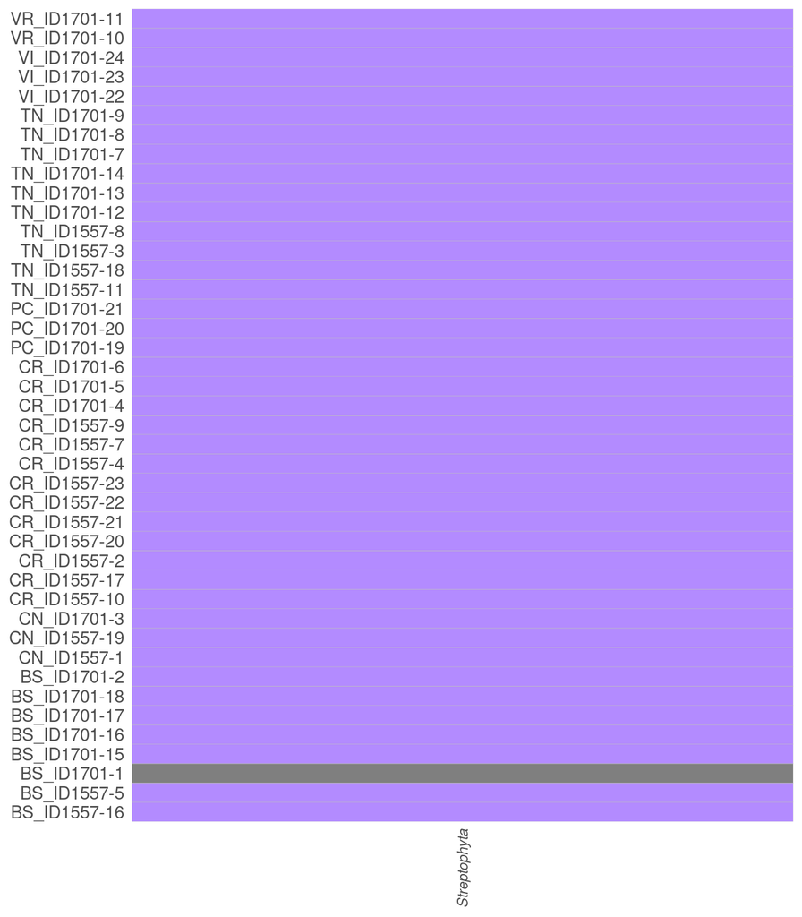

At Phylum level 100% of the reads are Streptophyta:

|  | x |
| --- | --- |
| Streptophyta | 100 |

Taking a look at the distribution of UN fractions:

| UN_fraction | samples |
| --- | --- |
| <25% | 0 |
| 25%-50% | 0 |
| 50%-75% | 2 |
| 75%-80% | 0 |
| 80%-85% | 2 |
| 85%-90% | 2 |
| 90%-95% | 16 |
| >95% | 20 |

## 10.2 Family

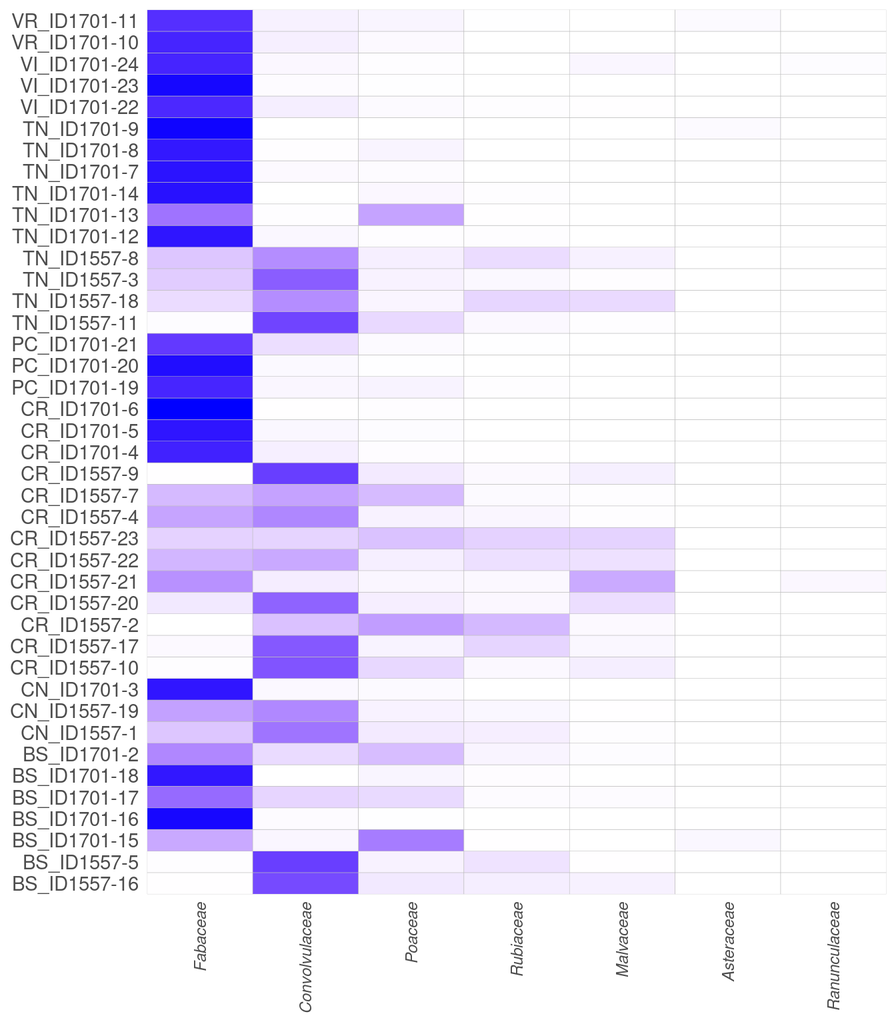

| UN_fraction | samples |
| --- | --- |
| <25% | 0 |
| 25%-50% | 0 |
| 50%-75% | 2 |
| 75%-80% | 0 |
| 80%-85% | 1 |
| 85%-90% | 1 |
| 90%-95% | 3 |
| >95% | 34 |

OTU incidence at family level:

|  | x |
| --- | --- |
| Fabaceae | 55.922 |
| Convolvulaceae | 26.618 |
| Poaceae | 9.419 |
| Rubiaceae | 4.318 |
| Malvaceae | 3.427 |
| Asteraceae | 0.181 |
| Ranunculaceae | 0.112 |
| Campanulaceae | 0.003 |

### 10.2.1 Compare GP vs. commercial

This is kept for historical reasons but not needed if we don’t include non GP samples anymore.

|  | all_samples | GP | commercial |
| --- | --- | --- | --- |
| Fabaceae | 57.207 | 55.922 | 70.38 |
| Convolvulaceae | 26.080 | 26.618 | 20.57 |
| Poaceae | 9.028 | 9.419 | 5.03 |
| Rubiaceae | 4.178 | 4.318 | 2.74 |
| Malvaceae | 3.237 | 3.427 | 1.29 |
| Asteraceae | 0.164 | 0.181 |  |
| Ranunculaceae | 0.102 | 0.112 |  |
| Campanulaceae | 0.003 | 0.003 |  |

## 10.3 Genus

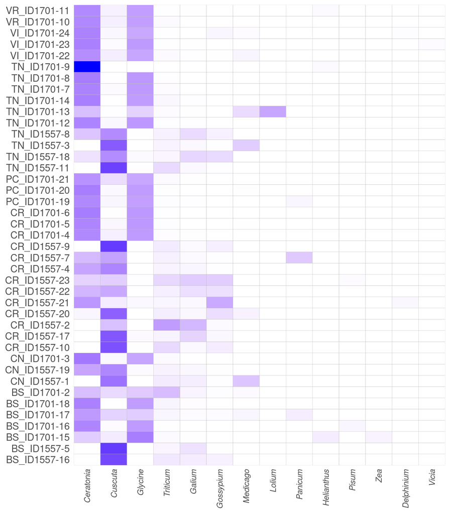

| UN_fraction | samples |
| --- | --- |
| <25% | 0 |
| 25%-50% | 0 |
| 50%-75% | 2 |
| 75%-80% | 0 |
| 80%-85% | 1 |
| 85%-90% | 1 |
| 90%-95% | 2 |
| >95% | 35 |

OTU incidence at genus level:

|  | x |
| --- | --- |
| Ceratonia | 33.912 |
| Cuscuta | 26.925 |
| Glycine | 21.155 |
| Triticum | 5.758 |
| Galium | 4.397 |
| Gossypium | 3.490 |
| Medicago | 1.890 |
| Lolium | 0.913 |
| Panicum | 0.809 |
| Helianthus | 0.275 |
| Pisum | 0.149 |
| Zea | 0.126 |
| Delphinium | 0.113 |
| Vicia | 0.060 |
| Secale | 0.023 |
| Lobelia | 0.003 |

### 10.3.1 Compare GP vs. commercial

This is kept for historical reasons but not needed if we don’t include non GP samples anymore.

|  | all_samples | GP | commercial |
| --- | --- | --- | --- |
| Ceratonia | 34.480 | 33.912 | 40.299 |
| Cuscuta | 26.361 | 26.925 | 20.585 |
| Glycine | 21.792 | 21.155 | 28.320 |
| Triticum | 5.389 | 5.758 | 1.600 |
| Galium | 4.250 | 4.397 | 2.738 |
| Gossypium | 3.295 | 3.490 | 1.291 |
| Medicago | 1.877 | 1.890 | 1.740 |
| Panicum | 1.038 | 0.809 | 3.392 |
| Lolium | 0.832 | 0.913 |  |
| Helianthus | 0.250 | 0.275 |  |
| Pisum | 0.136 | 0.149 |  |
| Zea | 0.115 | 0.126 |  |
| Delphinium | 0.103 | 0.113 |  |
| Vicia | 0.055 | 0.060 |  |
| Secale | 0.021 | 0.023 |  |
| Tripidium | 0.003 |  | 0.034 |
| Lobelia | 0.003 | 0.003 |  |

## 10.4 Species

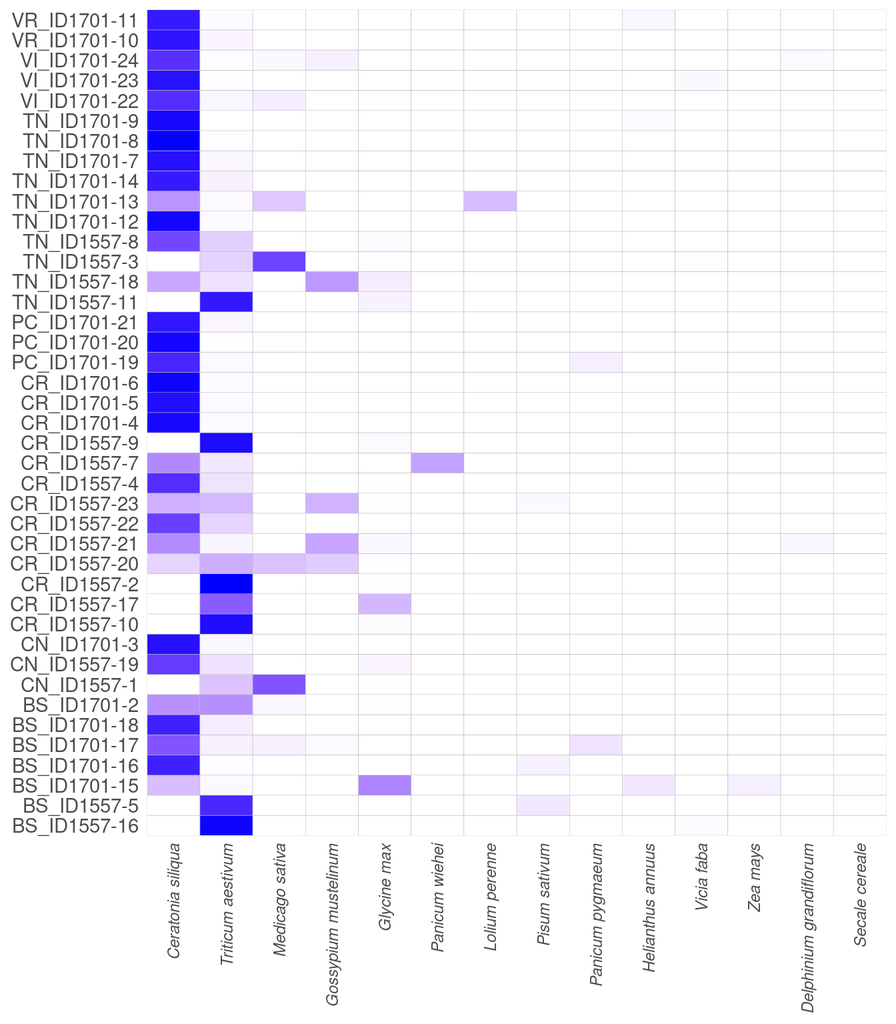

| UN_fraction | samples |
| --- | --- |
| <25% | 0 |
| 25%-50% | 0 |
| 50%-75% | 0 |
| 75%-80% | 1 |
| 80%-85% | 1 |
| 85%-90% | 1 |
| 90%-95% | 1 |
| >95% | 37 |

OTU incidence at species level:

|  | x |
| --- | --- |
| Ceratonia siliqua | 61.439 |
| Triticum aestivum | 23.221 |
| Medicago sativa | 5.490 |
| Gossypium mustelinum | 3.543 |
| Glycine max | 2.808 |
| Panicum wiehei | 0.964 |
| Lolium perenne | 0.691 |
| Pisum sativum | 0.482 |
| Panicum pygmaeum | 0.445 |
| Helianthus annuus | 0.374 |
| Vicia faba | 0.172 |
| Zea mays | 0.165 |
| Delphinium grandiflorum | 0.146 |
| Secale cereale | 0.030 |
| Galium murale | 0.024 |
| Cuscuta reflexa | 0.008 |

### 10.4.1 Compare GP vs. commercial

This is kept for historical reasons but not needed if we don’t include non GP samples anymore.

|  | all_samples | GP | commercial |
| --- | --- | --- | --- |
| Ceratonia siliqua | 61.835 | 61.439 | 65.894 |
| Triticum aestivum | 23.396 | 23.221 | 25.184 |
| Medicago sativa | 5.245 | 5.490 | 2.738 |
| Gossypium mustelinum | 3.228 | 3.543 |  |
| Glycine max | 2.627 | 2.808 | 0.770 |
| Panicum pygmaeum | 0.880 | 0.445 | 5.346 |
| Panicum wiehei | 0.878 | 0.964 |  |
| Lolium perenne | 0.630 | 0.691 |  |
| Pisum sativum | 0.439 | 0.482 |  |
| Helianthus annuus | 0.341 | 0.374 |  |
| Vicia faba | 0.156 | 0.172 |  |
| Zea mays | 0.150 | 0.165 |  |
| Delphinium grandiflorum | 0.133 | 0.146 |  |
| Secale cereale | 0.028 | 0.030 |  |
| Galium murale | 0.022 | 0.024 |  |
| Cuscuta reflexa | 0.007 | 0.008 |  |
| Tripidium kanashiroi | 0.003 |  | 0.029 |
| Tripidium arundinaceum | 0.002 |  | 0.027 |
| Glycine stenophita | 0.001 |  | 0.011 |

# 11 Diversity analysis

There are many ways to quantify complexity with the aim of comparing communities objectively. The two main categories of methods are known as alpha diversity and beta diversity [Whittaker, 1960]. Alpha diversity measures the diversity within a single sample and is based on the number and relative abundance of taxa at some rank (e.g. species, family). Beta diversity also uses the number of relative abundance of taxa at some rank, but measures variation between samples. In other words, an alpha diversity statistic describes a single sample and a beta diversity statistic describes how two samples compare.

Common alpha diversity statistics include Shannon diversity, which measures how difficult it is to predict the identity of a randomly chosen organism inside a sample; and Simpson diversity, which represents the probability that two randomly chosen organisms are the same species.

Beta diversity is a way to quantify the differences between two communities. There are several possible metrics available, the two more commonly used being *Bray–Curtis* beta diversity and *Weighted Unifrac* beta diversity. [**CITATION NEEDED**]. Given that it consists of a series of pair-wise comparisons between samples, beta diversity takes naturally the shape of a triangular matrix. In is thus common to represent beta diversity after doing Multi Dimensional Scaling, so that the two most meaningful dimensions are plotted and cluster could emerge (if present).

All diversity statistics were computed using the R package *vegan* [Oksanen et al., 2019]

References:

- Whittaker, Robert Harding. 1960. “Vegetation of the Siskiyou Mountains, Oregon and California.” Ecological Monographs 30 (3). Wiley Online Library: 279–338.
- Jari Oksanen, F. Guillaume Blanchet, Michael Friendly, Roeland Kindt, Pierre Legendre, Dan McGlinn, Peter R. Minchin, R. B. O’Hara, Gavin L. Simpson, Peter Solymos, M. Henry H. Stevens, Eduard Szoecs and Helene Wagner (2019). vegan: Community Ecology Package. R package version 2.5-6. https://CRAN.R-project.org/package=vegan

## 11.1 Alpha diversity - grana vs. non grana

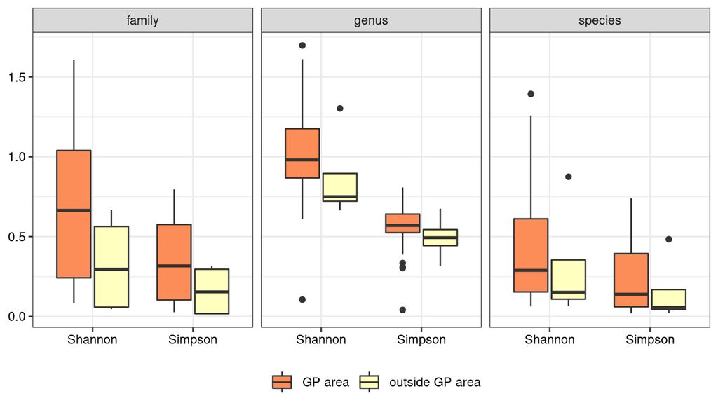

| test | family | genus | species |
| --- | --- | --- | --- |
| Shannon - GP area | 0.684 | 1.038 | 0.460 |
| Shannon - outside GP area | 0.326 | 0.867 | 0.311 |
| Simpson - GP area | 0.350 | 0.557 | 0.245 |
| Simpson - outside GP area | 0.160 | 0.494 | 0.155 |

We can formally verify the consistency of this trend via a statistical test. Unfortunately we cannot use the classical Student’s T test because the data are not normal (verified via Shapiro test for normality, data not reported). We must thus use the Wilcoxon rank sum test. The next table reports the p-values (alternative hypothesis: diversity are significantly different between grana and non-grana):

| level | Shannon_pvalue | Simpson_pvalue |
| --- | --- | --- |
| family | 0.108 | 0.083 |
| genus | 0.128 | 0.267 |
| species | 0.322 | 0.285 |

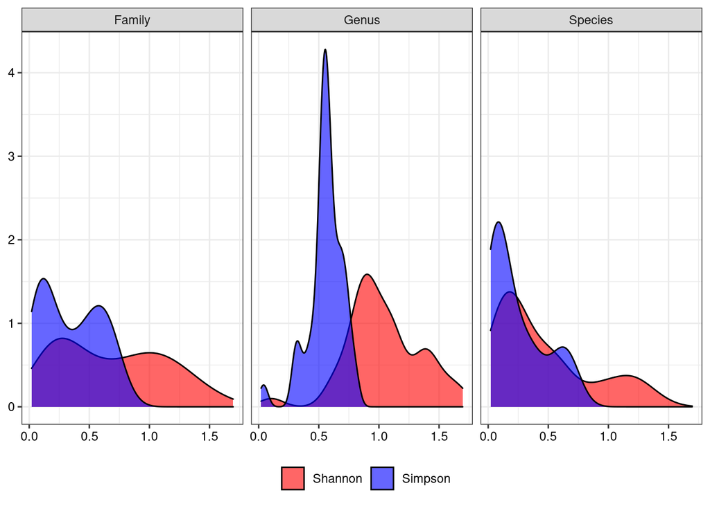

### 11.1.1 Open question: are diary sources uniform?

When I see data coming from a single diary (e.g. CN911) does it mean that the milk was produced **in the same farm**?

## 11.2 Alpha diversity, provinces

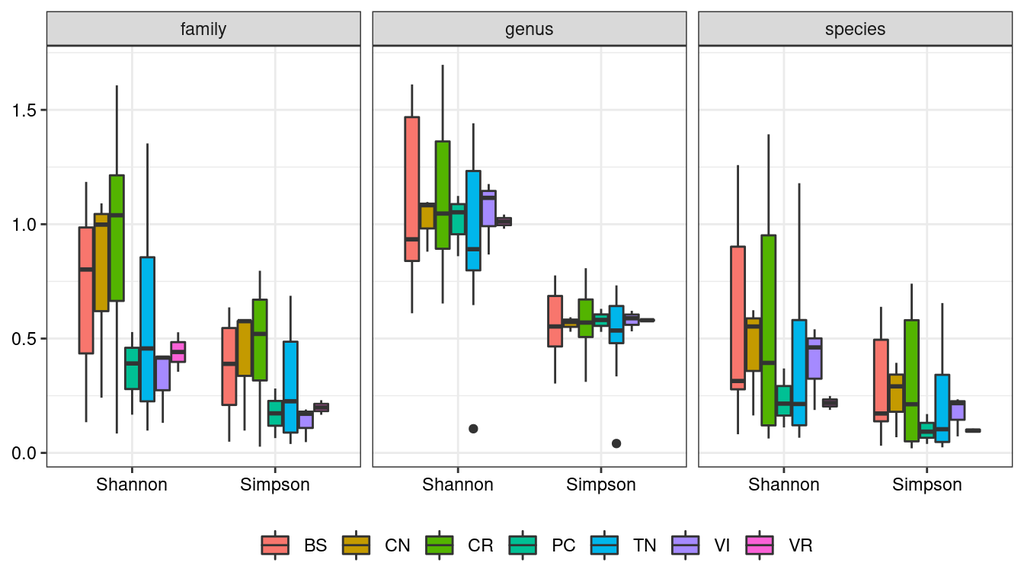

Given that we have multiple groups (i.e. multiple provinces) we can perform an analysis of variance (ANOVA), which will tell if there are any statistically significant differences between the groups. The p-values are reported in the following table:

| level | Shannon_pvalue | Simpson_pvalue |
| --- | --- | --- |
| family | 0.219 | 0.205 |
| genus | 0.924 | 0.955 |
| species | 0.857 | 0.792 |

What is apparent from the plot is confirmed from the statistical analysis: very little statistical difference at this stage (all p-values > 0.05).

## 11.3 Rarefaction curves

The following plot shows the rarefaction curves, where each line represents a sample. This plot links the amount of detected species as a function of the number of reads. Intuitively, if the reads are too few not all species will be detected. But after a certain point more reads are not useful because no more species are detected. Labels for samples are not reported to avoid plot overcrowding, but could be put back if required.

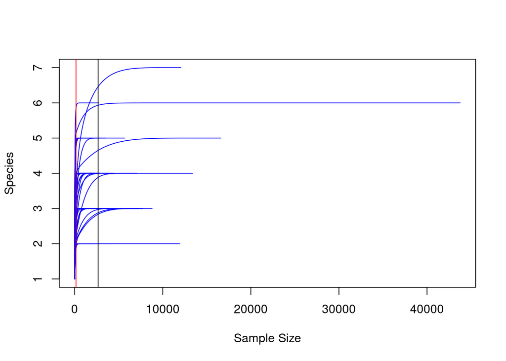

Zooming a bit:

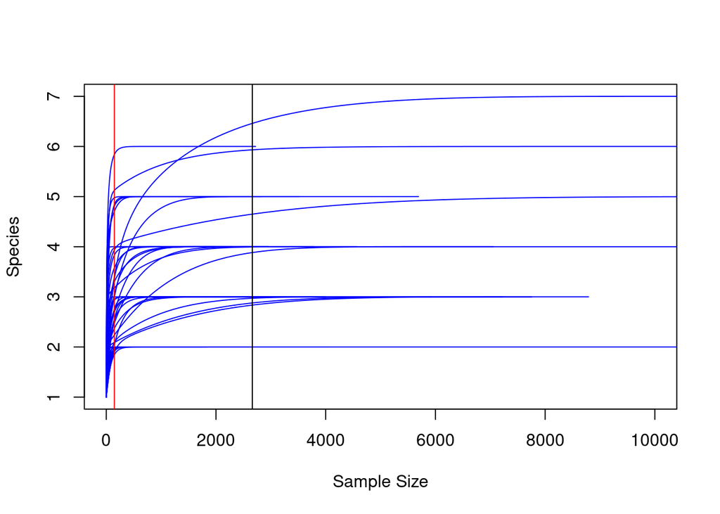

The plot is a bit problematic. Each blue line represents a sample. As the number of reads grows, the number of species found in each sample grows as well, but up to a point. In fact, the lines are expected to saturate and become flat, since each sample contains a certain amount of species.

| threshold | samples |
| --- | --- |
| 250 | 2 |
| 500 | 6 |
| 750 | 8 |
| 1000 | 11 |
| 2000 | 17 |
| 3000 | 27 |
| 7000 | 36 |
| 10000 | 40 |
| 13000 | 42 |

The conclusion is that a non negligible fraction of the samples (a third? two thirds?) could have used more reads.

## 11.4 Rarefaction curves, with UN

Same as above, but including UN in the plots:

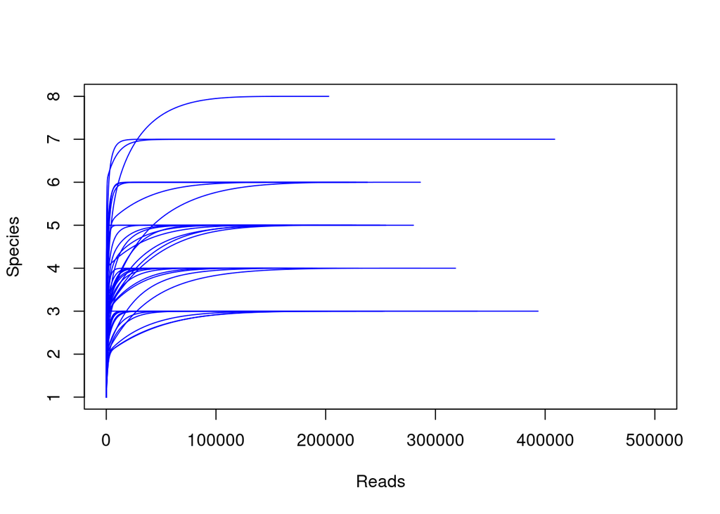

## 11.5 Beta diversity

I’ve introduced the concept of beta diversity at the beginning of this section. For simplicity all shown data are at “species” level, and using the “Bray-Curtis” metric. I found little difference using other parameters, however.

### 11.5.1 By type, grana vs. non grana

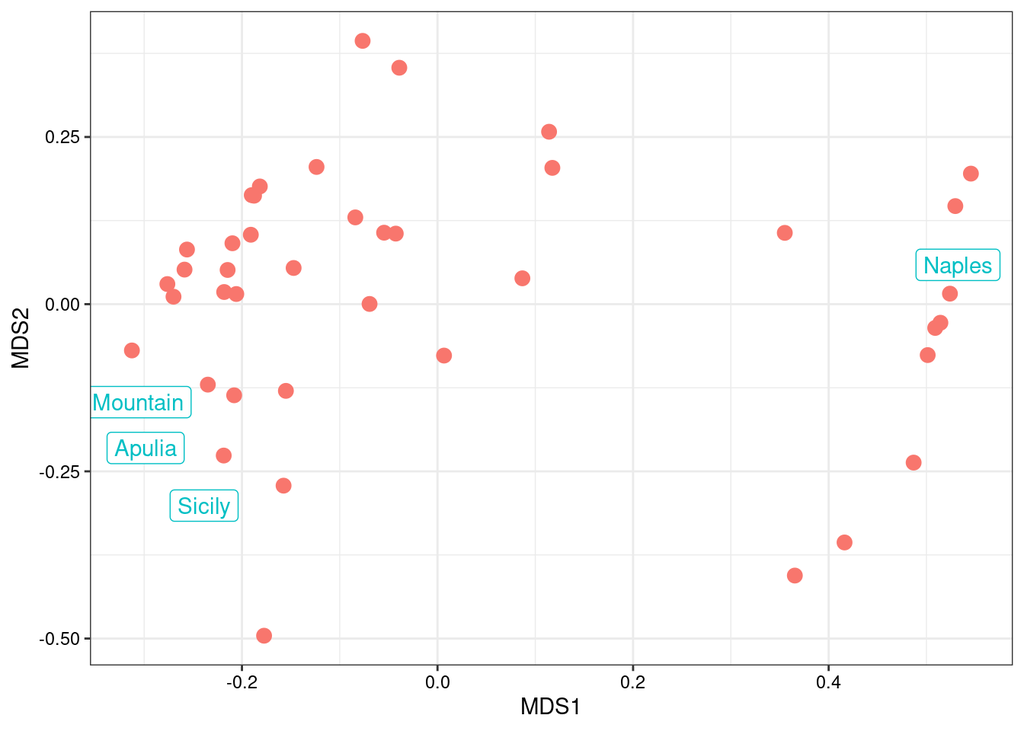

In this plot each milk sample from the grana consortium is represented with a red dot. The four non-grana milk are reported as blue labels. A few considerations:

- the milk samples are highly divided in two clusters, amplifying the general structure already seen in alpha diversity analysis
- the non-grana “Na” sample is separated from the other three, in contrast to what appeared from the alpha diversity (where the “Sicilia” sample was very different)

### 11.5.2 By province

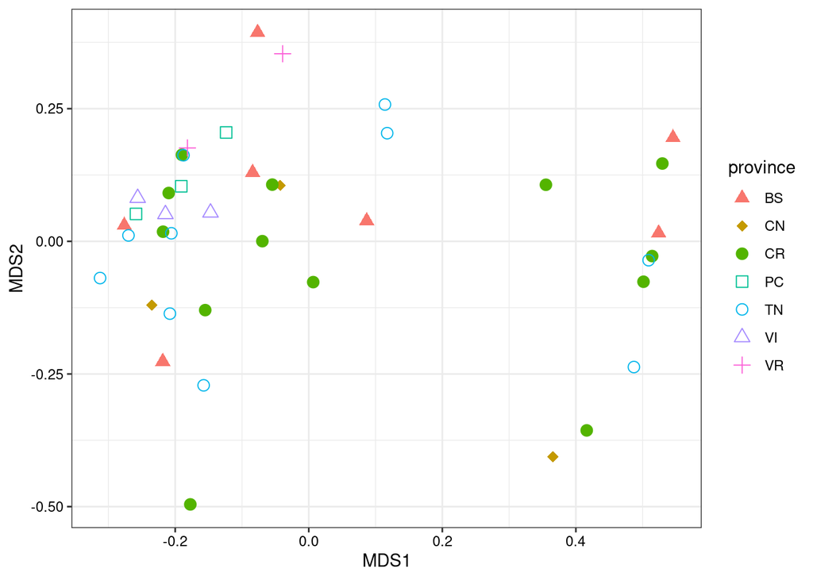

The data are exactly the same as in the previous plot, but here I highlight the geographical source. Unfortunately, not many patterns are visible.

### 11.5.3 By ccf

I plot again the same data, but highlighting extraction method - it was very easy to do :)

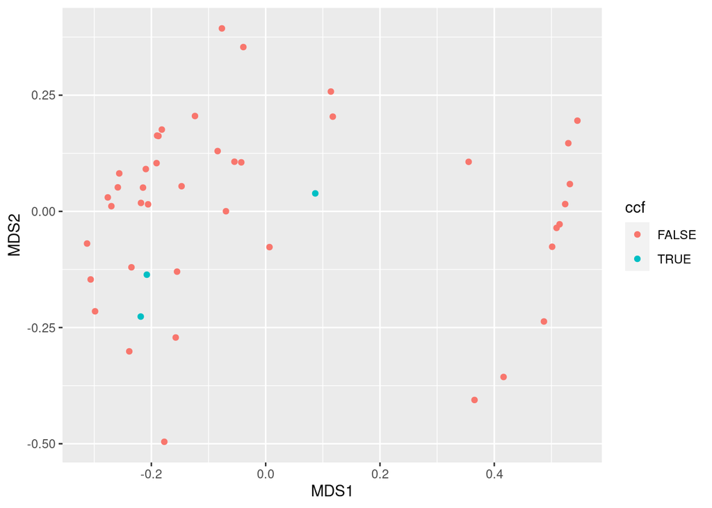

### 11.5.4 By sampling date

I’ve investigated the sampling date, too, to see if it could explain the visible clusters, with little succes. Data not reported for brevity.

### 11.5.5 By use of silage

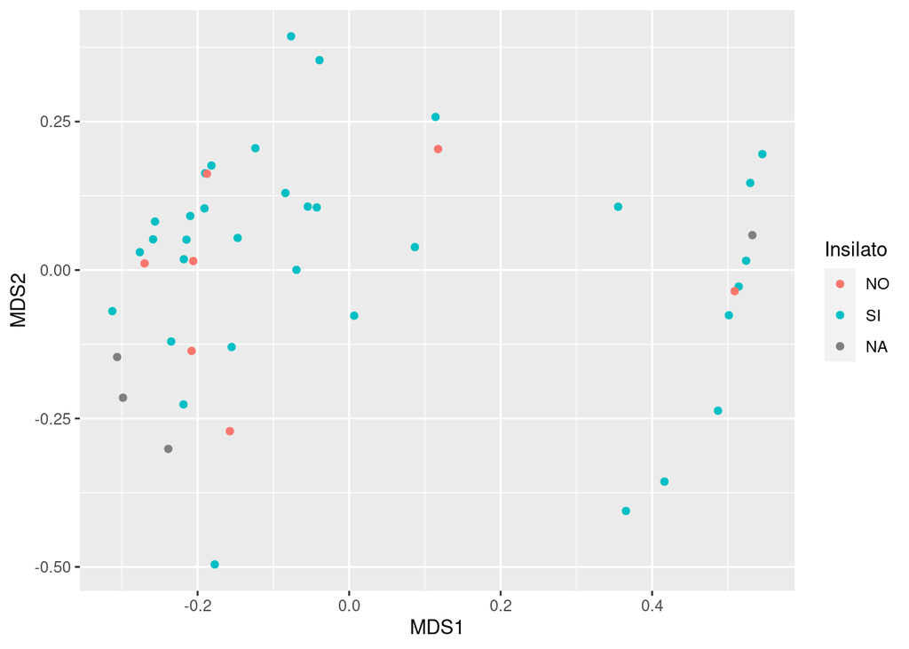

All samples with no silage are from TN province. The rightmost sample (the only one in the right cluster) is marked TN342_3000_ID1557-11.

### 11.5.6 Fully labelled

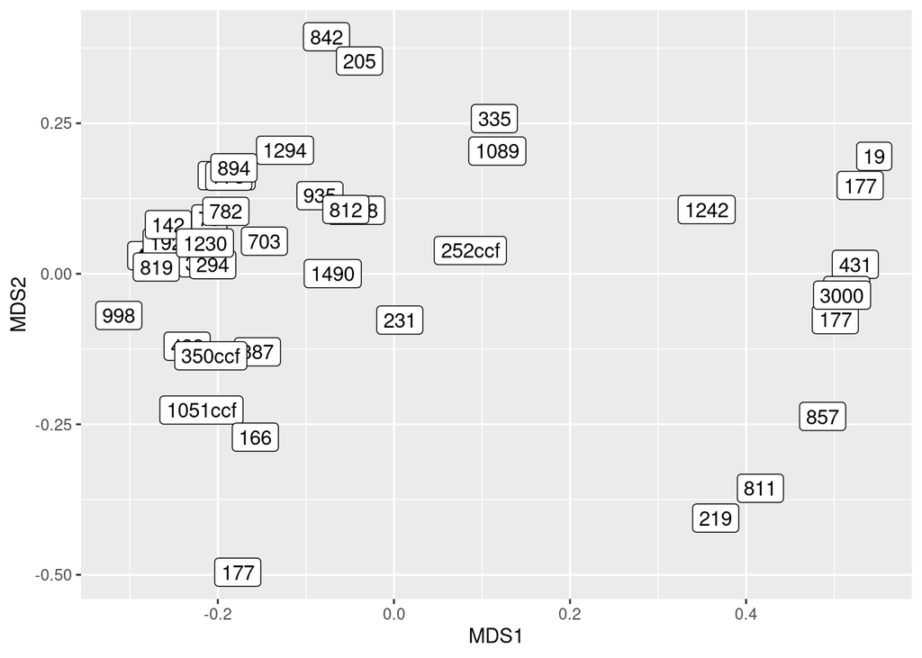

For better visualization, here’s a wider version:

Download beta_labelled.png

# 12 Taxon abundance

[TODO]

# 13 Riassunto per relazione tecnica

Per compensare la natura intrinsecamente frammentaria delle informazioni ottenute sono stati implementati dei filtri che eliminassero i dati con un basso livello di affidabilità. A tal fine tutte le OTU con numerosità minore di cinque reads sono state scartate.

Per procedere con le analisi ogni campione è stato quindi considerato come un ecosistema isolato, permettendo così di utilizzare gli strumenti statistici sviluppati in ambito ecologico. I due approcci metodologici principali mirano a fornire misure oggettive e comparabili della diversità biologica presente in ciacuna comunità e prendono il nome di parametri di diversità alfa e beta (alpha e beta diversity). La diversità alfa misura la ricchezza biologica all’interno di ogni singolo campioni, e si basa sul numero el’abbondanza relativa di “individui” (nel nostro caso, abbondanza di OTU) al livello tassonomico scelto per l’analisi. Anche la diversità beta fa uso delle informazioni sulla ricchezza biologica, ma misura la variazione tra comunità. In altre parole, la diversità alfa descrive un singolo campione, mentre la diversità beta confronta due campioni.

La diversità alfa può essere misurata utilizzando diversi coefficienti statistici. Per questa analisi abbiamo usato due tra gli indici più comuni, l’indice di Shannon e l’indice di Simpson. Per la diversità beta abbiamo usato l’indice Bray-Curtis. Dato che la diversità beta confronta coppie di campioni è spesso utile visualizzare i risultati dopo averne risotto la dimensionalità con una tecnica come il Multi Dimensional Scaling.